# CSDE 502 Winter 2021, Assignment 9

1767428

```r
pacman::p_load(
  tidyverse,
  magrittr,
  knitr,
  kableExtra,
  readstata13,
  haven,
  pdftools,
  curl,
  ggplot2,
  captioner
)

figure_nums <- captioner(prefix = "Figure")
table_nums <- captioner(prefix = "Table")

# path to this file name
if (!interactive()) {
    fnamepath <- knitr::current_input(dir = TRUE)
} else {
    fnamepath <- ""
}
```

*Explanation*: This assignment is intended to give you more practice delving into the Add Health data set and in manipulating additional variables.

*Instructions*:

1. Make sure your Rmd file has no local file system dependencies (i.e., anyone should be able to recreate the output HTML using only the Rmd source file).
2. Make a copy of this Rmd file and add answers below each question. The code that generated the answers should be included, as well as the complete source code for the document.  
   Put your answers within the **$\lt$div class=“answer”$\gt$…$\lt$/div$\gt$** tags so they will show up within the blue boxes with red borders.
3. Change the YAML header above to identify yourself and include contact information.
4. For any tables or figures, include captions and cross-references and any other document automation methods as necessary.
5. Make sure your output HTML file looks appealing to the reader.
6. Upload the final Rmd to your github repository.
7. Download [`assn_id.txt`](http://staff.washington.edu/phurvitz/csde502_winter_2021/assignments/assn_id.txt) and include the URL to your Rmd file on github.com.
8. Create a zip file from your copy of `assn_id.txt` and upload the zip file to the Canvas site for Assignment 1. *The zip file should contain only the text file. Do not include any additional files in the zip file–everything should be able to run from the file you uploaded to github.com. Please use zip format and not 7z or any other compression/archive format.*

# 1

**Using the full household roster (you’ll need to go back the full raw data source, [21600-0001-Data.dta](http://staff.washington.edu/phurvitz/csde502_winter_2021/data/21600-0001-Data.dta.zip)), create the following variables for each respondent. Document any decisions that you make regarding missing values, definitions, etc. in your narrative as well as in the R code. Include a frequency tabulation and a histogram of each result.**

```r
# download and unzip the larger data set
myUrl <- "http://staff.washington.edu/phurvitz/csde502_winter_2021/data/21600-0001-Data.dta.zip"
mytempdir <- tempdir()

# zip file in $temp -- basename gets just the file name from the URL and not the URL path;
#   file.path stitches the tempdir() path to the file name
zipfile <- file.path(mytempdir, basename(myUrl))

# dta file in $temp
dtafile <- tools::file_path_sans_ext(zipfile)

# check if the dta file exists
if (!file.exists(dtafile)) {
    # if the dta file doesn't exist, check for the zip file
    # check if the zip file exists, download if necessary
    if (!file.exists(zipfile)) {
        curl::curl_download(url = myUrl, destfile = zipfile)
    }
    # unzip the downloaded zip file
    if (file.exists(zipfile)) {
        unzip(zipfile = zipfile, exdir = mytempdir)
    }
}

# if the data set has not been read, read it in
if (!exists("ahcomplete")) {
    data <- haven::read_dta(dtafile)
}
```

## 1.1

**Total number in household**

*Table 1: Total number in household*

```r
hh <- data %>%
  map(~ attributes(.)$label) %>%
  unlist() %>%
  str_detect(regex("household", ignore_case = TRUE))



# data[hh] %>%
#     map(~ attributes(.)$label)


# data[hh]$S27 %>%
#   attributes %>%
#   extract2("labels")

house_num <- data[hh]$S27[data[hh]$S27 < 7][!is.na(data[hh]$S27[data[hh]$S27 < 7])]


table(house_num) %>%
  kable() %>%
  kable_styling(full_width = FALSE, position = "left",
                bootstrap_options = c("striped", "hover", "condensed", "responsive"))
```

| house_num | Freq |
| --- | --- |
| 1 | 24 |
| 2 | 239 |
| 3 | 853 |
| 4 | 1564 |
| 5 | 1095 |
| 6 | 822 |

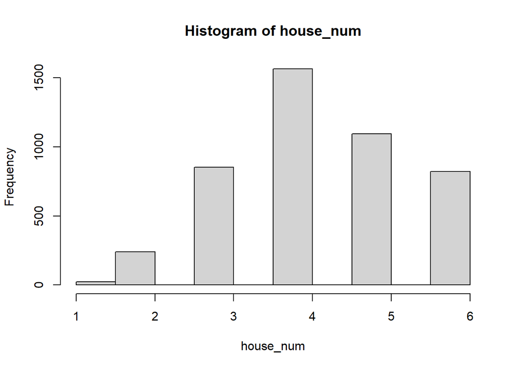

```r
hist(house_num)
```

*Figure 1: Total number in household*

## 1.2

**Number of sisters**

*Table 2: Number of sisters*

```r
temp <- data %>%
  dplyr::select(matches("H1HR3.*")) == 8


sis <- temp %>%
  as.data.frame() %>%
  rowSums()


sis %>%
  table() %>%
  kable() %>%
  kable_styling(full_width = FALSE, position = "left",
                bootstrap_options = c("striped", "hover", "condensed", "responsive"))
```

| . | Freq |
| --- | --- |
| 0 | 3355 |
| 1 | 2284 |
| 2 | 654 |
| 3 | 171 |
| 4 | 32 |
| 5 | 5 |
| 6 | 2 |
| 7 | 1 |

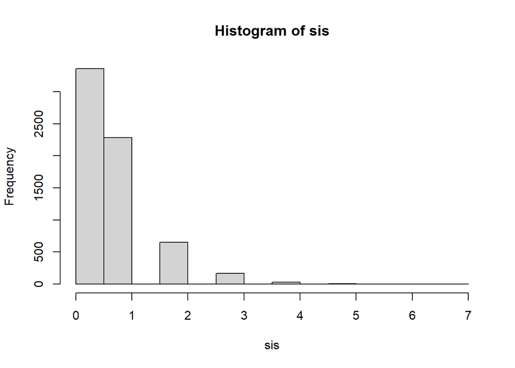

```r
hist(sis)
```

*Figure 2: Number of sisters*

## 1.3

**Number of brothers**

*Table 3: Number of brothers*

```r
temp <- data %>%
  dplyr::select(matches("H1HR3.*")) == 5


bro <- temp %>%
  as.data.frame() %>%
  rowSums()


bro %>%
  table() %>%
  kable() %>%
  kable_styling(full_width = FALSE, position = "left",
                bootstrap_options = c("striped", "hover", "condensed", "responsive"))
```

| . | Freq |
| --- | --- |
| 0 | 3181 |
| 1 | 2326 |
| 2 | 764 |
| 3 | 199 |
| 4 | 28 |
| 5 | 4 |
| 6 | 1 |
| 8 | 1 |

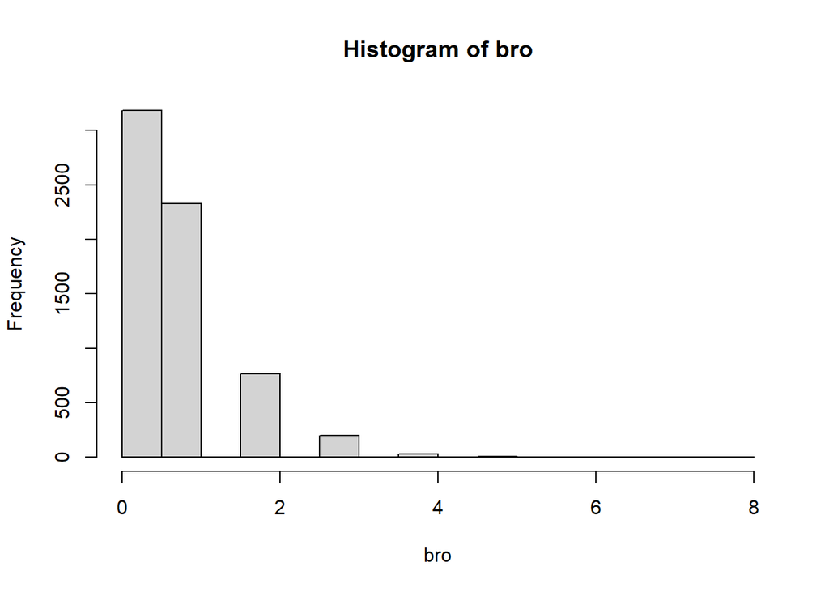

```r
hist(bro)
```

*Figure 3: Number of brothers*

## 1.4

**Total number of siblings**

*Table 4: Total number of siblings*

```r
temp_s <- data %>%
  dplyr::select(matches("H1HR3.*")) == 8



temp_b <- data %>%
  dplyr::select(matches("H1HR3.*")) == 5


sib <- temp_s + temp_b



sib <- sib %>%
  as.data.frame() %>%
  rowSums()


sib %>%
  table() %>%
  kable() %>%
  kable_styling(full_width = FALSE, position = "left",
                bootstrap_options = c("striped", "hover", "condensed", "responsive"))
```

| . | Freq |
| --- | --- |
| 0 | 1543 |
| 1 | 2499 |
| 2 | 1537 |
| 3 | 590 |
| 4 | 209 |
| 5 | 86 |
| 6 | 27 |
| 7 | 9 |
| 9 | 2 |
| 10 | 1 |
| 12 | 1 |

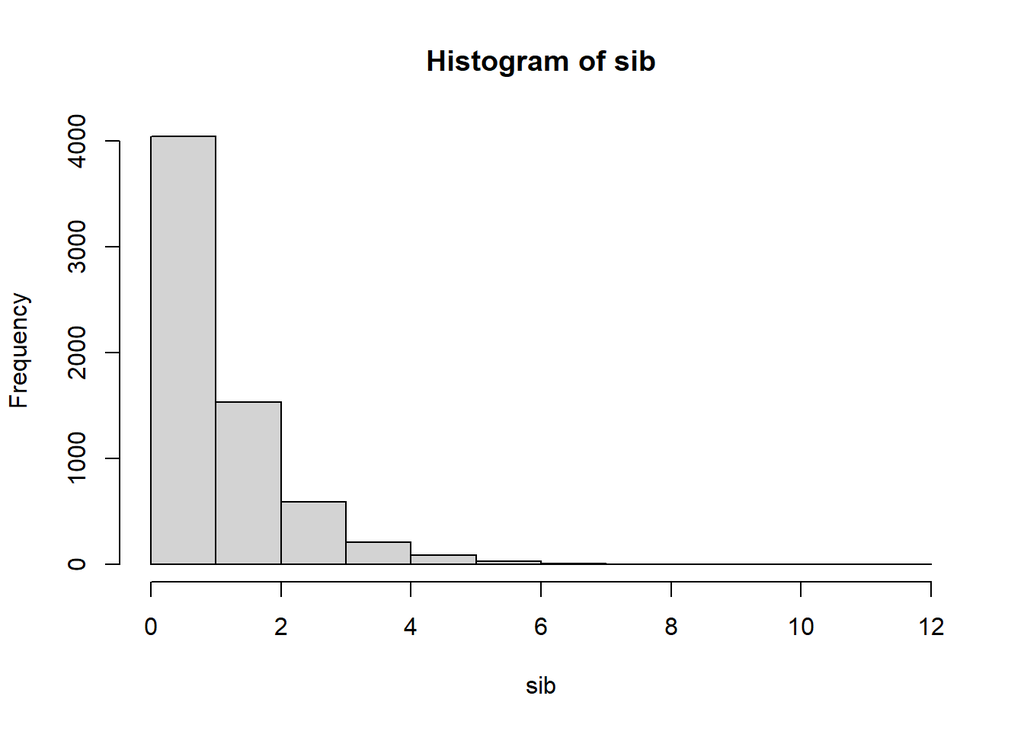

```r
hist(sib)
```

*Figure 4: Total number of siblings*

# 2

**What proportion of students live with two biological parents? Include the analysis in your R code.**

```r
pro <- sum(data$S26 == 1, na.rm = T)/ (sum(data$S26 == 1, na.rm = T) + sum(data$S26 == 0, na.rm = T))
```

The proportion of students live with two biological parents is 0.44.

# 3

Rendered at `2022-03-11 08:43:40`

## 3.1 Source code

File is at G:/My Drive/UW/21WIN_Demography/CSDE502/csde502_2022_assignment_09.Rmd.

### 3.1.1 R code used in this document

```r
pacman::p_load(
  tidyverse,
  magrittr,
  knitr,
  kableExtra,
  readstata13,
  haven,
  pdftools,
  curl,
  ggplot2,
  captioner
)

figure_nums <- captioner(prefix = "Figure")
table_nums <- captioner(prefix = "Table")

# path to this file name
if (!interactive()) {
    fnamepath <- knitr::current_input(dir = TRUE)
} else {
    fnamepath <- ""
}

# download and unzip the larger data set
myUrl <- "http://staff.washington.edu/phurvitz/csde502_winter_2021/data/21600-0001-Data.dta.zip"
mytempdir <- tempdir()

# zip file in $temp -- basename gets just the file name from the URL and not the URL path;
#   file.path stitches the tempdir() path to the file name
zipfile <- file.path(mytempdir, basename(myUrl))

# dta file in $temp
dtafile <- tools::file_path_sans_ext(zipfile)

# check if the dta file exists
if (!file.exists(dtafile)) {
    # if the dta file doesn't exist, check for the zip file
    # check if the zip file exists, download if necessary
    if (!file.exists(zipfile)) {
        curl::curl_download(url = myUrl, destfile = zipfile)
    }
    # unzip the downloaded zip file
    if (file.exists(zipfile)) {
        unzip(zipfile = zipfile, exdir = mytempdir)
    }
}

# if the data set has not been read, read it in
if (!exists("ahcomplete")) {
    data <- haven::read_dta(dtafile)
}



hh <- data %>%
  map(~ attributes(.)$label) %>%
  unlist() %>%
  str_detect(regex("household", ignore_case = TRUE))



# data[hh] %>%
#     map(~ attributes(.)$label)


# data[hh]$S27 %>%
#   attributes %>%
#   extract2("labels")

house_num <- data[hh]$S27[data[hh]$S27 < 7][!is.na(data[hh]$S27[data[hh]$S27 < 7])]


table(house_num) %>%
  kable() %>%
  kable_styling(full_width = FALSE, position = "left",
                bootstrap_options = c("striped", "hover", "condensed", "responsive"))

hist(house_num)



temp <- data %>%
  dplyr::select(matches("H1HR3.*")) == 8


sis <- temp %>%
  as.data.frame() %>%
  rowSums()


sis %>%
  table() %>%
  kable() %>%
  kable_styling(full_width = FALSE, position = "left",
                bootstrap_options = c("striped", "hover", "condensed", "responsive"))


hist(sis)



temp <- data %>%
  dplyr::select(matches("H1HR3.*")) == 5


bro <- temp %>%
  as.data.frame() %>%
  rowSums()


bro %>%
  table() %>%
  kable() %>%
  kable_styling(full_width = FALSE, position = "left",
                bootstrap_options = c("striped", "hover", "condensed", "responsive"))


hist(bro)


temp_s <- data %>%
  dplyr::select(matches("H1HR3.*")) == 8



temp_b <- data %>%
  dplyr::select(matches("H1HR3.*")) == 5


sib <- temp_s + temp_b



sib <- sib %>%
  as.data.frame() %>%
  rowSums()


sib %>%
  table() %>%
  kable() %>%
  kable_styling(full_width = FALSE, position = "left",
                bootstrap_options = c("striped", "hover", "condensed", "responsive"))



hist(sib)



pro <- sum(data$S26 == 1, na.rm = T)/ (sum(data$S26 == 1, na.rm = T) + sum(data$S26 == 0, na.rm = T))


cat(readLines(fnamepath), sep = '\n')
```

### 3.1.2 Complete Rmd code

```r
cat(readLines(fnamepath), sep = '\n')
```

```
---
title: "CSDE 502 Winter 2021, Assignment 9"
author: "1767428"
output:
    bookdown::html_document2:
        number_sections: true
        self_contained: true
        code_folding: hide
        toc: true
        toc_float:
            collapsed: true
            smooth_scroll: false
    pdf_document:
        number_sections: true
        toc: true
        fig_cap: yes
        keep_tex: yes
urlcolor: blue
---

<!-- This is a CSS style sheet for the answers -->
<style>
h1 {
  font-size: 22px;}

h2 {
  font-size: 18px;}

h3 {
  font-size: 18px;}

p {
  font-size: 16px;}

.answer {
  font-size: 18px;
  background-color: lightblue;
  border: 2px solid red;
  border-radius: 12px;
  padding: 5px;
```

[output cut: 284 more lines]

````

<hr>
Rendered at <tt>`r Sys.time()`</tt>

## Source code
File is at `r fnamepath`.

### R code used in this document
```{r ref.label=knitr::all_labels(), echo=TRUE, eval=FALSE}
```

### Complete Rmd code
```{r comment=''}
cat(readLines(fnamepath), sep = '\n')
```
````